# Introduction to Python Project : FoodHub Data Analysis

### **Question 10**: What is the mean order delivery time? [1 mark]

```python
# Write the code here
mean_order_delivery_time = data['delivery_time'].mean()
print(f"Mean order delivery time: {mean_order_delivery_time:.2f} mins")
```

```
Mean order delivery time: 24.16 mins
```

#### Observations:

- 24 mins (approx) or '24 mins, 9 seconds' is the mean order delivery time

### **Question 11:** The company has decided to give 20% discount vouchers to the top 3 most frequent customers. Find the IDs of these customers and the number of orders they placed. [1 mark]

```python
# Write the code here
data.groupby(['customer_id']).size().sort_values(ascending=False).head(3)
```

| customer_id | 0 |
| --- | --- |
| 52832 | 13 |
| 47440 | 10 |
| 83287 | 9 |

**dtype:** int64

#### Observations:

Following are the top 3 customers with their respective orders, eligible for the 20% discount vouchers

| Customer Id | Order count |
| --- | --- |
| 52832 | 13 |
| 47440 | 10 |
| 83287 | 9 |

### **Question 12**: Perform a multivariate analysis to explore relationships between the important variables in the dataset. (It is a good idea to explore relations between numerical variables as well as relations between numerical and categorical variables) [10 marks]

Exploring the relationship between the following variables using multivariate analysis

1. Customer & cost_of_the_order
2. Customer & cuisine_type & cost_of_the_order
3. Cuisine_type & cost_of_the_order
4. Cuisine_type & food_preparation_time, delivery_time
5. Order count by day of the week and cuisine type
6. Average cost_of_the_order & day_of_the_week and cuisine type
7. Top Restaurants and total time by day of the week
8. Restaurant_name & total_cost_of_the_order (aggregate)
9. Average 'total time' & day_of_the_week
10. Rating, Restaurant and Cuisine type
11. Day_of_the_week & rating
12. Correlation between rating, total time, cost of the order

#### [Multivariate 1] Customer and Cost of the order

Lets check the total cost of order by customer

```
count    1200.000000
mean       16.456487
std         6.591341
min         4.750000
25%        12.130000
50%        15.040000
75%        20.785000
max        33.320000
Name: avg_order_value, dtype: float64
----------
```

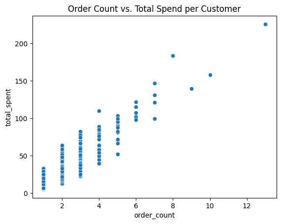

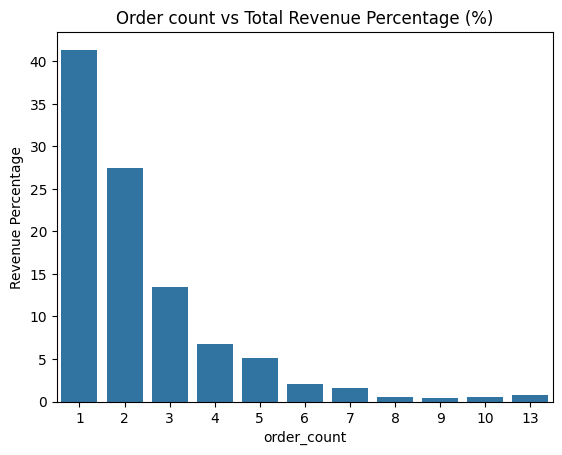

```python
customer_spending = data.groupby("customer_id")["cost_of_the_order"].agg(["count", "sum", "mean"])
customer_spending.rename(columns={"count": "order_count", "sum": "total_spent", "mean": "avg_order_value"}, inplace=True)

print(customer_spending['avg_order_value'].describe().T)
print("-"*10)

sns.scatterplot(data=customer_spending, x="order_count", y="total_spent")
plt.title("Order Count vs. Total Spend per Customer")
plt.show()

print("-"*10)
orders_cost_by_count = customer_spending.groupby('order_count',  as_index=False)['total_spent'].sum()
orders_cost_by_count['percentage'] = (orders_cost_by_count['total_spent'] / orders_cost_by_count['total_spent'].sum()) * 100

plt.title('Order count vs Total Revenue Percentage (%)')
plt.ylabel('Revenue Percentage')
sns.barplot(data=orders_cost_by_count, x='order_count', y='percentage', legend=False)
plt.show()
```

**Observations**

#### [Multivariate 2] Customer, cuisine type, cost of the order

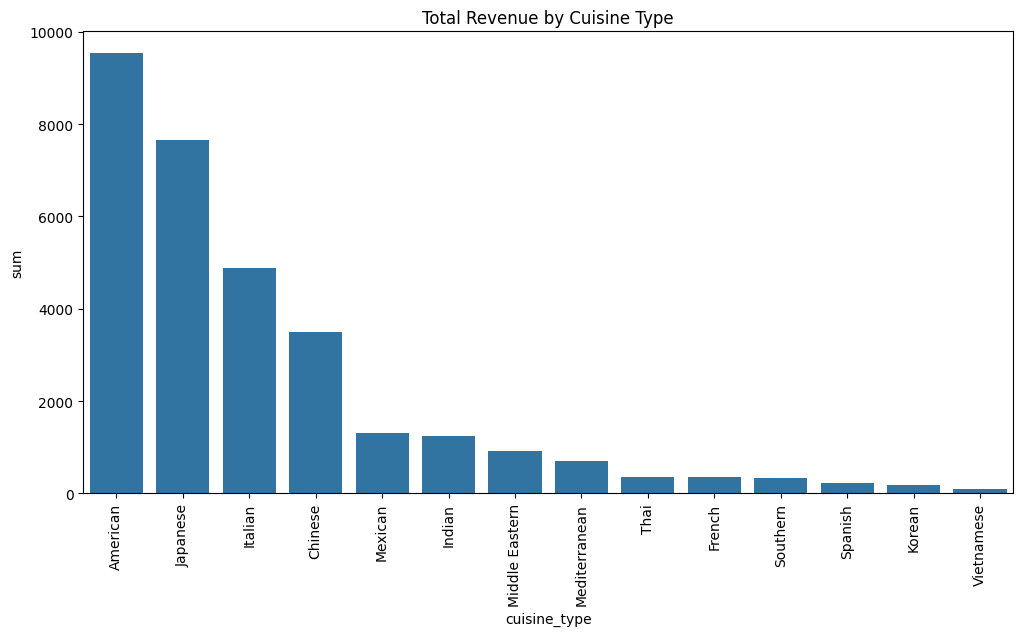

```python
customer_cuisine_spending = data.groupby(["customer_id", "cuisine_type"])["cost_of_the_order"].agg(["sum", "mean"]).reset_index()
rev_by_cuisine = customer_cuisine_spending.groupby("cuisine_type", as_index=False)['sum'].sum().sort_values(by='sum', ascending=False)
plt.figure(figsize=(12, 6))
plt.title("Total Revenue by Cuisine Type")
plt.xticks(rotation=90)
sns.barplot(data=rev_by_cuisine, x='cuisine_type', y='sum')
plt.show()
```

**Observations**

- Total spending by individual customers is high on American cuisine, followed by Japanese, Italian and Chinese

#### [Multivariate 3] Cuisine and cost of the order

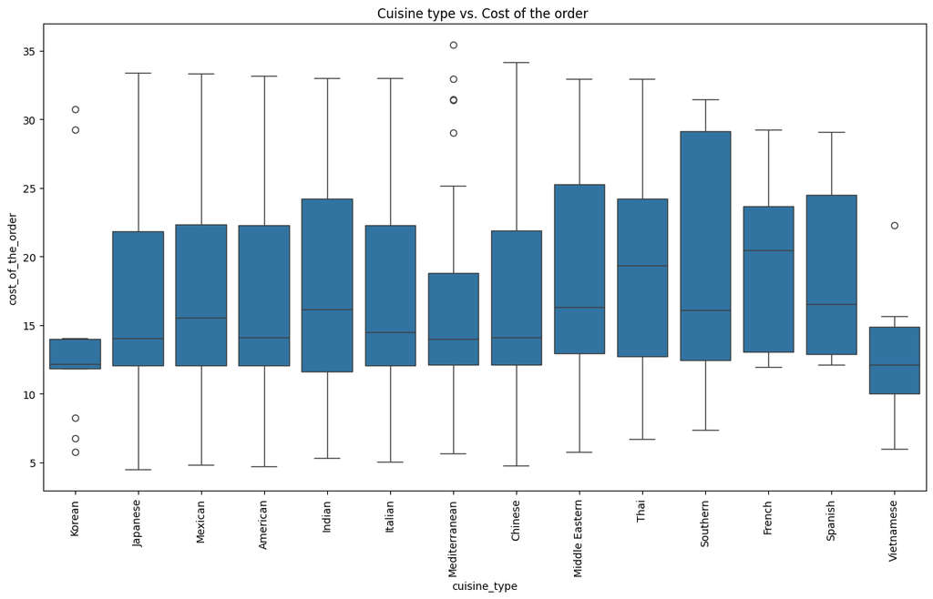

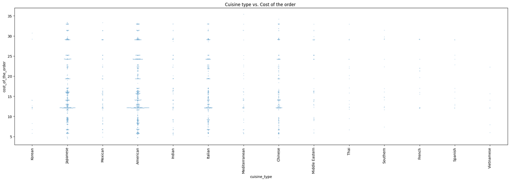

```python
plt.figure(figsize=(15,8))
sns.boxplot(data=data, x='cuisine_type', y='cost_of_the_order')
plt.title("Cuisine type vs. Cost of the order ")
plt.xticks(rotation=90);
plt.show()

print("-" * 10)

plt.figure(figsize=(25, 7))
plt.title("Cuisine type vs. Cost of the order ")
sns.swarmplot(data = data, x = "cuisine_type", y = "cost_of_the_order", size = 1)
plt.xticks(rotation=90);
plt.show()
```

**Observations:**

- Average cost of the order is high on French and Thai cuisines, around `$`20, inferred from the Box plot
- Average cost of the 4 top preferred cuisines (American, Japanese, Italian and Chinese is comparable and below `$`15. High number of orders are concentrated around this and is visible from scatter plot

#### [Multivariate 4] Cuisine & Food preparation time, delivery time

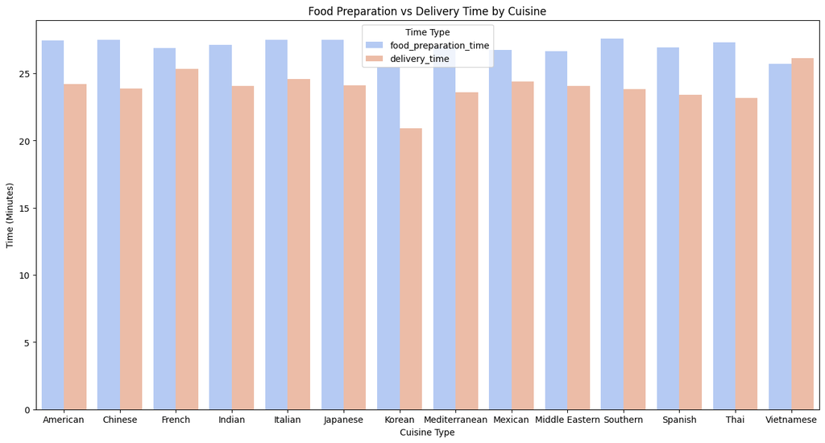

```python
# Melt the DataFrame to make it suitable for a grouped bar chart
data_avg = data.groupby("cuisine_type")[["food_preparation_time", "delivery_time"]].mean().reset_index()
data_melted = data_avg.melt(id_vars=["cuisine_type"], value_vars=["food_preparation_time", "delivery_time"],
                    var_name="Time_Type", value_name="Minutes")

# Plot the grouped bar chart
plt.figure(figsize=(16, 8))
sns.barplot(data=data_melted, x="cuisine_type", y="Minutes", hue="Time_Type", palette="coolwarm")

# Customize the chart
plt.title("Food Preparation vs Delivery Time by Cuisine")
plt.xlabel("Cuisine Type")
plt.ylabel("Time (Minutes)")
plt.legend(title="Time Type")
plt.show()
```

**Observations** :

- Average delivery times are lesser than average food preparation times across all cuisines except for Vietnamese
- Top selling cuisines (American, Japanese, Italian, Chinese) have comparable delivery and food preparation times respectively.

#### [Multivariate 5] Order count by day of the week and cuisine type

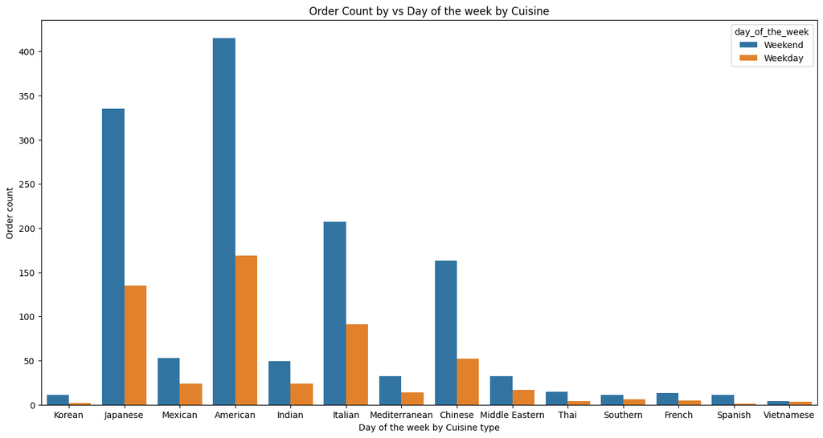

```python
plt.figure(figsize=(16, 8))
plt.title("Order Count by vs Day of the week by Cuisine")
plt.ylabel("Order count")
plt.xlabel("Day of the week by Cuisine type")
sns.countplot(data=data, x='cuisine_type', hue='day_of_the_week');
plt.show()
```

**Observations:**

- Across all cuisines, significantly High number of orders are received on Weekends
- On Weekends as well as week days, Top selling cuisines are American, Japanese Italian, Chinese

#### [Multivariate 6] Average cost of the order by day of the week and cuisine type

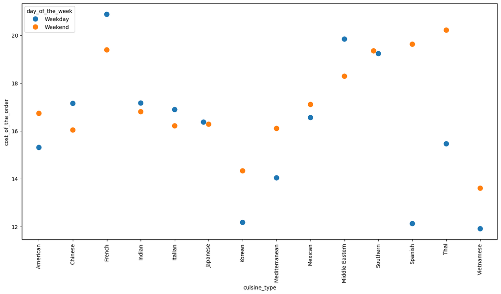

```python
plt.figure(figsize=(16, 8))
average_data = data.groupby(["day_of_the_week", "cuisine_type"])["cost_of_the_order"].mean().reset_index()
sns.swarmplot(data = average_data, x = "cuisine_type", y = "cost_of_the_order", hue='day_of_the_week', size=10)
plt.xticks(rotation=90);
```

**Observations:**

- For American cuisine, the average cost per order increases during the weekends compared to other high selling cuisines Chinese, Italian & Japanese.
- For Japanese cuisines, the average cost spend per order on weekends and weekdays are almost similar
- Both these observations are leading to higher revenues on weekends as the order count is higher on weekends for these cuisines (observed earlier)

#### [Multivariate 7] Top Restaurants and total time by day of the week

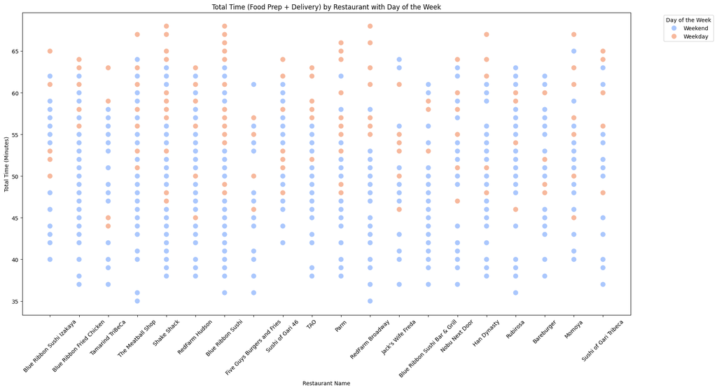

```python
data["total_time"] = data["food_preparation_time"] + data["delivery_time"]

top_restaurants = (
    data.groupby(["restaurant_name"])
    .size()
    .reset_index(name="order_count")
    .sort_values(by="order_count", ascending=False)
    .head(20)
)

filtered_data = data[data["restaurant_name"].isin(top_restaurants["restaurant_name"])]

plt.figure(figsize=(20, 10))
sns.scatterplot(data=filtered_data, x="restaurant_name", y="total_time", hue="day_of_the_week", palette="coolwarm", s=100)

# Customize
plt.xticks(rotation=45)
plt.title("Total Time (Food Prep + Delivery) by Restaurant with Day of the Week")
plt.xlabel("Restaurant Name")
plt.ylabel("Total Time (Minutes)")
plt.legend(title="Day of the Week", bbox_to_anchor=(1.05, 1), loc="upper left")
plt.show()
```

**Observations:**

- For the top 20 restaurants with highest order count, the total time taken (food prep time + delivery time) for most of the orders is high on week days compared to weekend orders

#### [Multivariate 8] Restaurants and Total Cost of the orders received

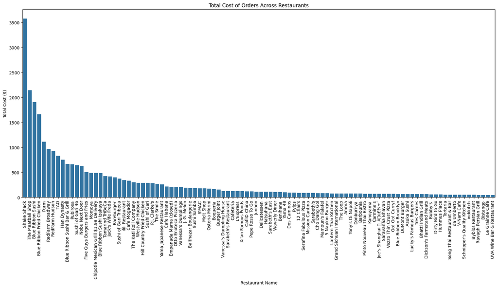

```
               restaurant_name  total_cost
136                Shake Shack     3579.53
153          The Meatball Shop     2145.21
21           Blue Ribbon Sushi     1903.95
20   Blue Ribbon Fried Chicken     1662.29
109                       Parm     1112.76
```

|  | count | mean | std | min | 25% | 50% | 75% | max |
| --- | --- | --- | --- | --- | --- | --- | --- | --- |
| total_cost | 178.0 | 175.925955 | 394.615994 | 5.72 | 23.84 | 54.615 | 124.8425 | 3579.53 |

```python
total_cost_per_restaurant = data.groupby("restaurant_name")["cost_of_the_order"].sum().reset_index()
total_cost_per_restaurant = total_cost_per_restaurant.rename(columns={"cost_of_the_order": "total_cost"})
total_cost_per_restaurant.sort_values(by="total_cost", ascending=False, inplace=True)


plt.figure(figsize=(20, 8))
# sns.scatterplot(data=total_cost_per_restaurant.head(100), x="restaurant_name", y="total_cost", color="blue")
sns.barplot(x="restaurant_name", y="total_cost", data=total_cost_per_restaurant.head(100))

# Customize
plt.xticks(rotation=90)
plt.title("Total Cost of Orders Across Restaurants")
plt.xlabel("Restaurant Name")
plt.ylabel("Total Cost ($)")
plt.show()

print(total_cost_per_restaurant.head(5))
total_cost_per_restaurant.describe().T
```

**Observations:**

- Nearly 35% of the revenue is from the top 5 restaurants.
- Following are the top 5 restaurants from total revenue
  1. Shake Shack
  2. The Meatball Shop
  3. Blue Ribbon Sushi
  4. Blue Ribbon Fried Chicken
  5. Parm

#### [Multivariate 9] Average 'total order time' by day of the week

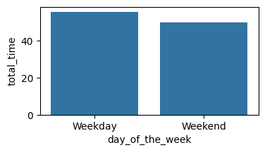

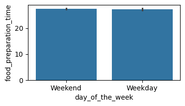

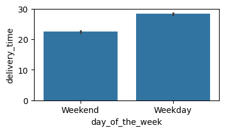

```python
data['total_time'] = data['food_preparation_time'] + data['delivery_time']
data_by_day = data.groupby('day_of_the_week', as_index=False)['total_time'].mean()

plt.figure(figsize=(4,2))
sns.barplot(data=data_by_day, x='day_of_the_week', y='total_time')
plt.show()

print("-" * 10)
data_by_day

print("-" * 10)
plt.figure(figsize=(4,2))
sns.barplot(data=data, x='day_of_the_week', y='food_preparation_time')
plt.show()

print("-" * 10)
plt.figure(figsize=(4,2))
sns.barplot(data=data, x='day_of_the_week', y='delivery_time')
plt.show()
```

- Average total time taken i.e., the sum of order preparation and delivery is higher on weekdays compared to weekeends
- Average Food preparation time is consistent on weekdays and weekends, but the delivery times are lesser on weekends compared to weekdays

#### [Multivariate 10] Rating, Restaurant and Cuisine type

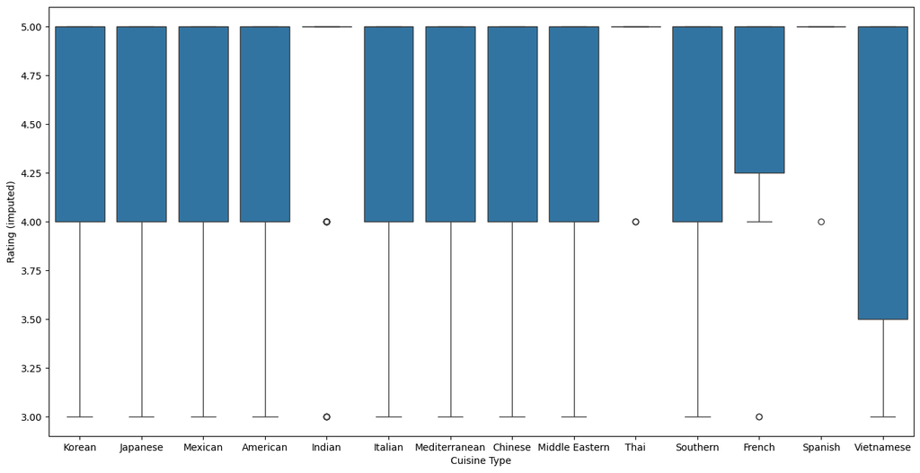

| cuisine_type | American | Chinese | French | Indian | Italian | Japanese | Korean | Mediterranean | Mexican | Middle Eastern | Southern | Spanish | Thai | Vietnamese |
| --- | --- | --- | --- | --- | --- | --- | --- | --- | --- | --- | --- | --- | --- | --- |
| count | 584.0 | 215.0 | 18.0 | 73.0 | 298.0 | 470.0 | 13.0 | 46.0 | 77.0 | 49.0 | 17.0 | 12.0 | 19.0 | 7.0 |
| mean | 4.558219 | 4.590698 | 4.611111 | 4.684932 | 4.630872 | 4.63617 | 4.384615 | 4.456522 | 4.636364 | 4.469388 | 4.470588 | 4.916667 | 4.842105 | 4.285714 |
| std | 0.683072 | 0.683522 | 0.697802 | 0.598069 | 0.649776 | 0.63445 | 0.767948 | 0.80847 | 0.626374 | 0.680136 | 0.624264 | 0.288675 | 0.374634 | 0.95119 |
| min | 3.0 | 3.0 | 3.0 | 3.0 | 3.0 | 3.0 | 3.0 | 3.0 | 3.0 | 3.0 | 3.0 | 4.0 | 4.0 | 3.0 |
| 25% | 4.0 | 4.0 | 4.25 | 5.0 | 4.0 | 4.0 | 4.0 | 4.0 | 4.0 | 4.0 | 4.0 | 5.0 | 5.0 | 3.5 |
| 50% | 5.0 | 5.0 | 5.0 | 5.0 | 5.0 | 5.0 | 5.0 | 5.0 | 5.0 | 5.0 | 5.0 | 5.0 | 5.0 | 5.0 |
| 75% | 5.0 | 5.0 | 5.0 | 5.0 | 5.0 | 5.0 | 5.0 | 5.0 | 5.0 | 5.0 | 5.0 | 5.0 | 5.0 | 5.0 |
| max | 5.0 | 5.0 | 5.0 | 5.0 | 5.0 | 5.0 | 5.0 | 5.0 | 5.0 | 5.0 | 5.0 | 5.0 | 5.0 | 5.0 |

```python
plt.figure(figsize=(16, 8))
plt.xlabel('Cuisine Type')
plt.ylabel('Rating (imputed)')
sns.boxplot(data=data, x='cuisine_type', y='new_rating')
plt.show()

data.groupby('cuisine_type')['new_rating'].describe().T
```

**Observations**

- None of the cuisines have ratings below 3
- Most of the Cuisines have their IQR in 4 to 5 rating range
- American, Japanese, Italian and Chinese have received most number of ratings

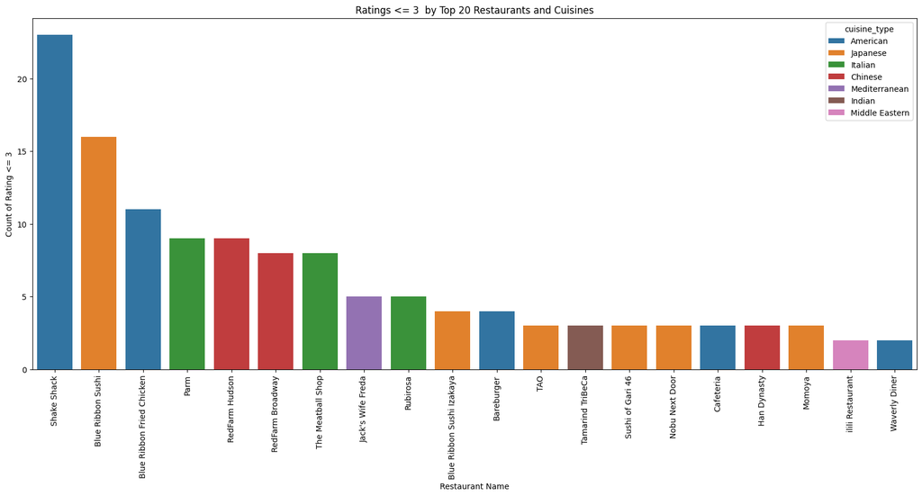

```python
data_grouped_by_rest = data[data['new_rating'] <= 3].groupby('restaurant_name', as_index=False)['cuisine_type'].value_counts().sort_values(by='count', ascending=False).head(20)
plt.figure(figsize=(20, 8))
plt.xticks(rotation=90)
plt.title("Ratings <= 3  by Top 20 Restaurants and Cuisines")
plt.xlabel("Restaurant Name")
plt.ylabel("Count of Rating <= 3")
sns.barplot(data=data_grouped_by_rest, x='restaurant_name', y='count', hue='cuisine_type')
plt.show()
```

**Observations**

- Shake Shak restaurant of American cuisine has most number of 3 Ratings
- Top revenue making restaurants receive more number of '3' ratings (Shake Shack, Blue Ribbon Sushi, Blue Ribbon Fried Chicken, RedFarm Hudson)

#### [Multivariate 11] Day of the week and Rating

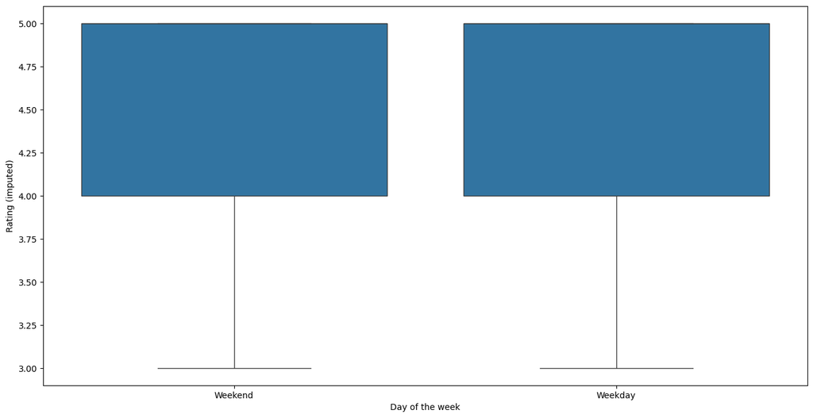

| day_of_the_week | Weekday | Weekend |
| --- | --- | --- |
| count | 547.0 | 1351.0 |
| mean | 4.570384 | 4.609919 |
| std | 0.690119 | 0.650599 |
| min | 3.0 | 3.0 |
| 25% | 4.0 | 4.0 |
| 50% | 5.0 | 5.0 |
| 75% | 5.0 | 5.0 |
| max | 5.0 | 5.0 |

```python
plt.figure(figsize=(16, 8))
plt.xlabel('Day of the week')
plt.ylabel('Rating (imputed)')
sns.boxplot(data=data, x='day_of_the_week', y='new_rating')
plt.show()

data.groupby('day_of_the_week')['new_rating'].describe().T
```

- Weekends have more ratings compared to weekdays. This can be inferred due to the number of orders received
- Weekends also have more lower ratings i.e., rating = 3 & this can be inferred due to the todal orders
- There is no significant difference in the average rating between weekends and weekdays. Ratings on weekends are marginally better, and could be related to the delivery time

#### [Multivariate 12] Correlation between rating, total time, cost of the order

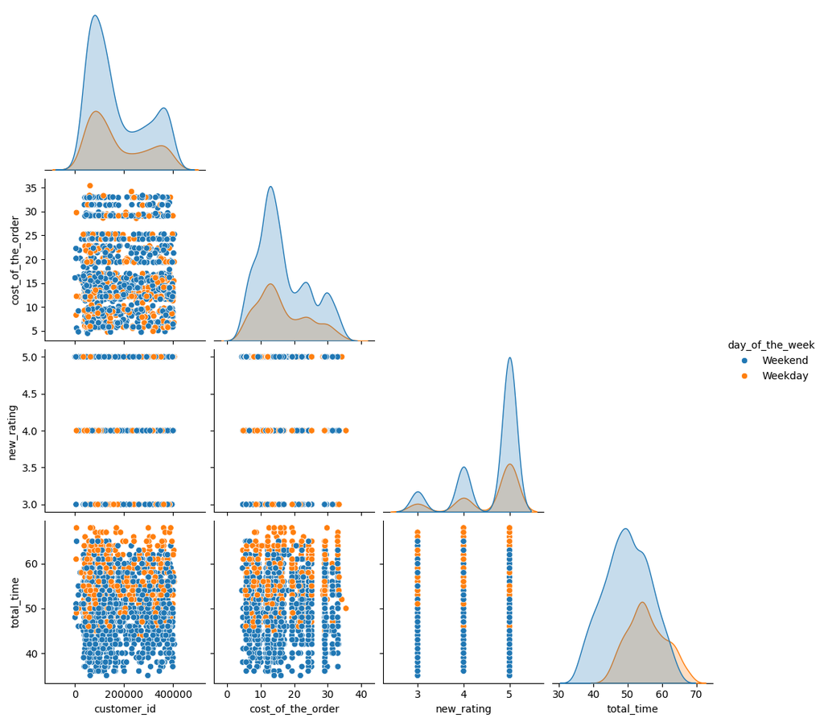

```python
sns.pairplot(data=data, vars=['customer_id', 'cost_of_the_order', 'new_rating', 'total_time'],  corner=True, hue='day_of_the_week')
plt.show();
```

**Observations**

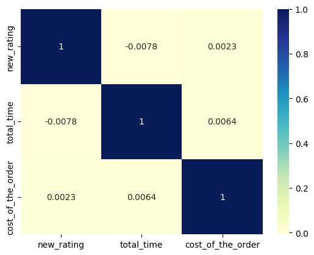

```python
sns.heatmap(data=data[['new_rating','total_time','cost_of_the_order']].corr(), annot=True, cmap='YlGnBu');
```

**Observations:**

- There is no significant correlation between new_rating','total_time', 'cost_of_the_order columns

```python
print("Total Time for Ratings == 3")
print(data[data['rating'] == 3]['total_time'].groupby(data['day_of_the_week']).mean())

print("\nTotal Time for Ratings > 3")
print(data[data['rating'] > 3]['total_time'].groupby(data['day_of_the_week']).mean())
```

```
Total Time for Ratings == 3
day_of_the_week
Weekday    54.666667
Weekend    50.640000
Name: total_time, dtype: float64

Total Time for Ratings > 3
day_of_the_week
Weekday    55.772563
Weekend    49.728838
Name: total_time, dtype: float64
```

Observations:

- Delivery, Food prep or total time is not impacting the ratings on weekend on weekdays

### **Question 13:** The company wants to provide a promotional offer in the advertisement of the restaurants. The condition to get the offer is that the restaurants must have a rating count of more than 50 and the average rating should be greater than 4. Find the restaurants fulfilling the criteria to get the promotional offer. [3 marks]

```python
# Write the code here
restaurant_stats = data.groupby("restaurant_name")["new_rating"].agg(["count", "mean"])
offer_fulfiling_restaurants = restaurant_stats[(restaurant_stats["count"] > 50) & (restaurant_stats["mean"] > 4)]
offer_fulfiling_restaurants
```

| restaurant_name | count | mean |
| --- | --- | --- |
| Blue Ribbon Fried Chicken | 96 | 4.552083 |
| Blue Ribbon Sushi | 119 | 4.521008 |
| Parm | 68 | 4.5 |
| RedFarm Broadway | 59 | 4.474576 |
| RedFarm Hudson | 55 | 4.490909 |
| Shake Shack | 219 | 4.561644 |
| The Meatball Shop | 132 | 4.689394 |

#### Observations:

Following are the restaurants that match the criteria of 'greater than 50 ratings' & 'mean rating greater than 4.

**Note** : This is based on the imputed rating data

1. Blue Ribbon Fried Chicken
2. Blue Ribbon Sushi
3. Parm
4. RedFarm Broadway
5. RedFarm Hudson
6. Shake Shack
7. The Meatball Shop

### **Question 14:** The company charges the restaurant 25% on the orders having cost greater than 20 dollars and 15% on the orders having cost greater than 5 dollars. Find the net revenue generated by the company across all orders. [3 marks]

```python
# Write the code here
orders_cost_above_20 = data[data['cost_of_the_order'] > 20]['cost_of_the_order'].sum()
print(orders_cost_above_20)
orders_cost_above_5 = data[(data['cost_of_the_order'] > 5) & (data['cost_of_the_order'] <= 20)]['cost_of_the_order'].sum()
print(orders_cost_above_5)
net_revenue = (orders_cost_above_20 * 0.25) + (orders_cost_above_5 * 0.15)
print(f"Net revenue generated by the company: ${net_revenue:.2f}")
```

```
14754.91
16517.170000000002
Net revenue generated by the company: $6166.30
```

#### Observations:

- The total revenue generated by the company across all orders is `$`6166.30

### **Question 15:** The company wants to analyze the total time required to deliver the food. What percentage of orders take more than 60 minutes to get delivered from the time the order is placed? (The food has to be prepared and then delivered.) [2 marks]

```python
# Write the code here
data['total_delivery_time'] = data['food_preparation_time'] + data['delivery_time']
orders_taking_more_than_60_mins = (data['total_delivery_time'] > 60).sum()
order_percent = (orders_taking_more_than_60_mins/len(data)) * 100
print(f"Number of orders with total time > 60 mins: {order_percent:.2f}")
```

```
Number of orders with total time > 60 mins: 10.54
```

#### Observations:

- Approximately 11% of orders (or 200 orders in total) take more than 60 mins to get delivered

### **Question 16:** The company wants to analyze the delivery time of the orders on weekdays and weekends. How does the mean delivery time vary during weekdays and weekends? [2 marks]

```python
# Write the code here
print("\nWeekend delivery time : ", data[data['day_of_the_week'] == 'Weekend']['delivery_time'].mean())
print("\nWeekday delivery time : ",data[data['day_of_the_week'] == 'Weekday']['delivery_time'].mean())
```

```
Weekend delivery time :  22.4700222057735

Weekday delivery time :  28.340036563071298
```

#### Observations:

- Delivery time on weekends is quicker compared to Weekends by approximately 6 mins. On weekdays delivery takes around 28+ minutes whereas on weekends it is only around 22+ minutes